# Language Attitudes on Pohnpei Example

Bradley Rentz

# Introduction

This document provides an example of using machine learning packages with R Markdown. The data used in this example come from a language attitudes survey conducted on the island of Pohnpei in the Federated States of Micronesia.

The dataset contains the following variables:

### Data Frame Summary

#### data

**Dimensions:** 301 x 18  
**Duplicates:** 0

Variable

Stats / Values

Freqs (% of Valid)

Graph

Missing

questionnaire_id  
[factor]

1 ( 0.3%)  
1 ( 0.3%)  
1 ( 0.3%)  
1 ( 0.3%)  
1 ( 0.3%)  
1 ( 0.3%)  
1 ( 0.3%)  
1 ( 0.3%)  
1 ( 0.3%)  
1 ( 0.3%)  
291 (96.7%)

[figure not shown]

0  
(0%)

survey_version  
[factor]

1. 1  
2. 2a  
3. 2b

142 (47.2%)  
91 (30.2%)  
68 (22.6%)

0  
(0%)

survey_language  
[factor]

1. eng  
2. pni

142 (47.2%)  
159 (52.8%)

0  
(0%)

age  
[factor]

1. 18 – 24  
2. 25 – 34  
3. 35 – 44  
4. 45 – 54  
5. 55 – 64  
6. 65 – 74  
7. 75+

83 (27.6%)  
84 (27.9%)  
59 (19.6%)  
43 (14.3%)  
23 ( 7.6%)  
7 ( 2.3%)  
2 ( 0.7%)

0  
(0%)

sex  
[factor]

1. Female  
2. Male

173 (57.5%)  
128 (42.5%)

0  
(0%)

birth_location  
[factor]

1. Pohnpei State  
2. Chuuk State  
3. USA  
4. Kosrae State  
5. Other  
6. RMI  
7. Yap State

240 (79.7%)  
8 ( 2.7%)  
24 ( 8.0%)  
9 ( 3.0%)  
9 ( 3.0%)  
4 ( 1.3%)  
7 ( 2.3%)

0  
(0%)

citizenship  
[factor]

1. FSM  
2. Other  
3. Palau  
4. Philippines  
5. RMI  
6. USA

269 (89.4%)  
5 ( 1.7%)  
2 ( 0.7%)  
3 ( 1.0%)  
1 ( 0.3%)  
21 ( 7.0%)

0  
(0%)

current_muni  
[factor]

1. Nett  
2. Kitti  
3. Madolenihmw  
4. Sokehs  
5. Uh

149 (49.5%)  
56 (18.6%)  
22 ( 7.3%)  
44 (14.6%)  
30 (10.0%)

0  
(0%)

time_fsm  
[factor]

1. 0 - 4 years  
2. 10 - 19 years  
3. 20 - 29 years  
4. 30 - 39 years  
5. 40 or more years  
6. 5 - 9 years

7 ( 2.3%)  
61 (20.3%)  
87 (28.9%)  
55 (18.3%)  
87 (28.9%)  
4 ( 1.3%)

0  
(0%)

time_pni  
[factor]

1. 0 - 4 years  
2. 5 - 9 years  
3. 10 - 19 years  
4. 20 - 29 years  
5. 30 - 39 years  
6. 40 or more years

20 ( 6.6%)  
7 ( 2.3%)  
53 (17.6%)  
81 (26.9%)  
50 (16.6%)  
90 (29.9%)

0  
(0%)

pni_current_place  
[factor]

1. 0 - 4 years  
2. 10 - 19 years  
3. 20 - 29 years  
4. 30 - 39 years  
5. 40 or more years  
6. 5 - 9 years

40 (13.3%)  
67 (22.3%)  
79 (26.2%)  
49 (16.3%)  
48 (16.0%)  
18 ( 6.0%)

0  
(0%)

travelled_abroad  
[factor]

1. No  
2. Yes

131 (43.5%)  
170 (56.5%)

0  
(0%)

education  
[factor]

1. Not high school graduate  
2. High school, diploma, or  
3. Some college, no degree  
4. Associate degree  
5. Bachelor’s degree  
6. Advanced degree

116 (38.5%)  
28 ( 9.3%)  
72 (23.9%)  
39 (13.0%)  
27 ( 9.0%)  
19 ( 6.3%)

0  
(0%)

elementary_type  
[factor]

1. Public school  
2. Private school  
3. Both

250 (83.1%)  
46 (15.3%)  
5 ( 1.7%)

0  
(0%)

hs_type  
[factor]

1. Public school  
2. Private school  
3. None

168 (55.8%)  
68 (22.6%)  
65 (21.6%)

0  
(0%)

current_village  
[factor]

1. Alauso  
2. Alohkapw  
3. Awak  
4. Awak Pah  
5. Awak Powe  
6. Chinatown  
7. Danpei  
8. Dien  
9. Dolekei  
10. Dolonier  
[ 67 others ]

1 ( 0.3%)  
2 ( 0.7%)  
6 ( 2.0%)  
5 ( 1.7%)  
1 ( 0.3%)  
1 ( 0.3%)  
3 ( 1.0%)  
3 ( 1.0%)  
2 ( 0.7%)  
7 ( 2.3%)  
270 (89.7%)

0  
(0%)

weights.trim  
[numeric]

Mean (sd) : 1 (0.8)  
min < med < max:  
0.2 < 0.8 < 5  
IQR (CV) : 1 (0.8)

125 distinct values

0  
(0%)

total_pni  
[numeric]

Mean (sd) : 13.8 (6.3)  
min < med < max:  
0 < 14 < 23  
IQR (CV) : 10 (0.5)

23 distinct values

0  
(0%)

# Analysis

The survey respondents were asked to select the language that they felt was most important to use in 25 different domains. The number of times a respondent selected Pohnpeian was counted to create the variable “total_pni”. The sample analysis uses random forests to see how respondents’ demographic and geographic (such as current place of residence) predict the number of times they selected Pohnpeian as the most important language. The analysis also uses survey weights that were created to help balance the unequal sampling across the island’s demographic groups.

## First model

The first step is to build the basic model random forest model. We will use the `h2o` package to do that and include all variables in the model using the default settings. We’ll use 5-fold cross-validation to evaluate the models. Note: Running the `h2o` package requires java to be installed.

```r
# turn data into h2o object

train.h2o <- as.h2o(data)
# train model with all the predictors and survey weights. Include 5-fold cross-validation
rf1 <- h2o.randomForest(x, y, train.h2o,weights_column="weights.trim",nfolds=5)
print(rf1)
```

```
## Model Details:
## ==============
##
## H2ORegressionModel: drf
## Model ID:  DRF_model_R_1562656303396_8
## Model Summary:
##   number_of_trees number_of_internal_trees model_size_in_bytes min_depth
## 1              50                       50               68512        10
##   max_depth mean_depth min_leaves max_leaves mean_leaves
## 1        16   12.22000         75        101    87.22000
##
##
## H2ORegressionMetrics: drf
## ** Reported on training data. **
## ** Metrics reported on Out-Of-Bag training samples **
##
## MSE:  21.98422
## RMSE:  4.688734
## MAE:  3.58184
## RMSLE:  0.5559309
## Mean Residual Deviance :  21.98422
##
##
##
## H2ORegressionMetrics: drf
## ** Reported on cross-validation data. **
## ** 5-fold cross-validation on training data (Metrics computed for combined holdout predictions) **
##
## MSE:  22.67421
## RMSE:  4.761744
## MAE:  3.599958
## RMSLE:  0.5517606
## Mean Residual Deviance :  22.67421
##
##
## Cross-Validation Metrics Summary:
##                              mean          sd cv_1_valid cv_2_valid
## mae                     3.5464041  0.36297944  3.8557441  3.0364425
## mean_residual_deviance  22.051128   3.9356227  24.344208   18.34072
## mse                     22.051128   3.9356227  24.344208   18.34072
## r2                     0.46023735 0.112267405 0.42664048 0.61889476
## residual_deviance       22.051128   3.9356227  24.344208   18.34072
## rmse                     4.655918   0.4321778  4.9339848  4.2826066
## rmsle                   0.5383656  0.06060206  0.5303756 0.62650555
##                        cv_3_valid cv_4_valid cv_5_valid
## mae                     2.8752286  3.7260828   4.238522
## mean_residual_deviance   13.58577    24.2203  29.764643
## mse                      13.58577    24.2203  29.764643
## r2                     0.61587906 0.45426923 0.18550326
## residual_deviance        13.58577    24.2203  29.764643
## rmse                     3.685888  4.9214125   5.455698
## rmsle                  0.37860078 0.58816147  0.5681846
```

```r
perf1 <- h2o.performance(rf1, train.h2o) # save model performance
print(perf1)
```

```
## H2ORegressionMetrics: drf
##
## MSE:  4.575731
## RMSE:  2.139096
## MAE:  1.582379
## RMSLE:  0.3618899
## Mean Residual Deviance :  4.575731
```

The first model has a mean squared error of 4.5757313 on the training dataset. Perhaps we can improve the model performance by tuning the model.

## Tuning the model

Random forests have several hyperparameters that can be changed with the goal of improving the model. We unfortunately do not know what they are beforehand so we have to specify a range of possible values and then randomly search through them until we find values that improve the model. It will take a very long time to test all the combinations so we randomly search within in a specified range of combinations and tell the algorithm to stop looking if after 10 models it does not find a new model that improves by a specified amount. This process takes about 20–30 minutes to run.

```r
# hyperparameter grid
# this code is not run since takes a long time.
hyper_grid.h2o <- list(
  ntrees      = seq(50, 500, by = 50),
  mtries      = seq(1, 15, by = 2),
  max_depth   = seq(20, 40, by = 5),
  min_rows    = seq(1, 5, by = 2),
  nbins       = seq(10, 30, by = 5),
  sample_rate = c(.55, .632, .75)
)

# random grid search criteria
search_criteria <- list(
  strategy = "RandomDiscrete",
  stopping_metric = "mse",
  stopping_tolerance = 0.005,
  stopping_rounds = 10,
  max_runtime_secs = 30*60
  )

# build grid search
random_grid <- h2o.grid(
  algorithm = "randomForest",
  grid_id = "rf_grid2",
  x = x,
  y = y,
  training_frame = train.h2o,
  hyper_params = hyper_grid.h2o,
  weights_column="weights.trim",
  search_criteria = search_criteria
  )

# collect the results and sort by our model performance metric of choice
grid_perf2 <- h2o.getGrid(
  grid_id = "rf_grid2",
  sort_by = "mse",
  decreasing = FALSE
  )
print(grid_perf2)
```

Since the model tuning takes a long time, we’ll just use the default settings for now, but in a real research setting the model should be tuned properly.

## Interpreting the model

There are several plots that we can use to help us interpret the model. To make the plots, we’ll use the `iml` package. Before we can make any of the plots, we have to save both our model and our data in a format that iml can use.

```r
# create a df with just the model predictor variables
features <- data %>% select(-1,-total_pni)

# create a vector of the responses
response <- data.model$total_pni

# Create custom predict function that returns the predicted values as a
#    vector
pred <- function(model, newdata)  {
  results <- as.data.frame(h2o.predict(model, as.h2o(newdata)))
  return(results$predict)
}

results <- as.data.frame(h2o.predict(rf1,as.h2o(data)))


# create predictor object for the random forest model
predictor.rf <- Predictor$new(
  model = rf1,
  data = features,
  y = response,
  predict.fun = pred,
  class = "regression"
  )
```

### Variable importance

We can view which predictor variables are the most important in predicting overall the total count of Pohnpeian selections.

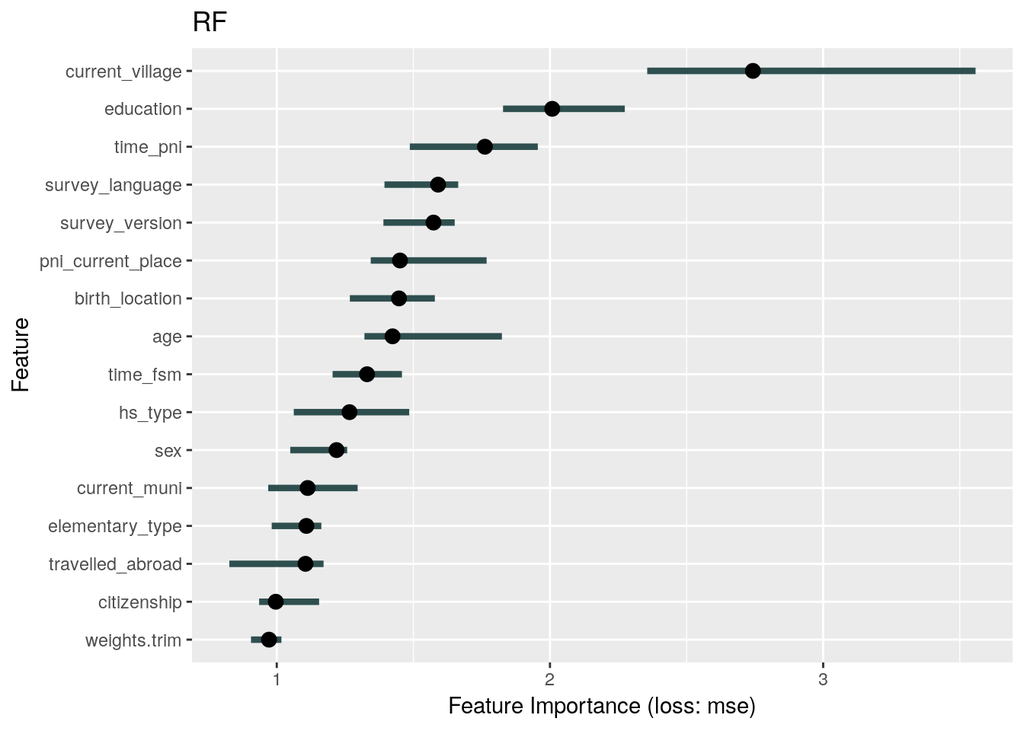

```r
imp.rf <- FeatureImp$new(predictor.rf, loss = "mse")
p1 <- plot(imp.rf) + ggtitle("RF")
p1
```

### Partial Dependence Plots

We can select categorical variables to see how their levels differ in predicted total Pohnpeian counts. The plot below shows all the predicted outcomes for each of the individuals who the specified education level.

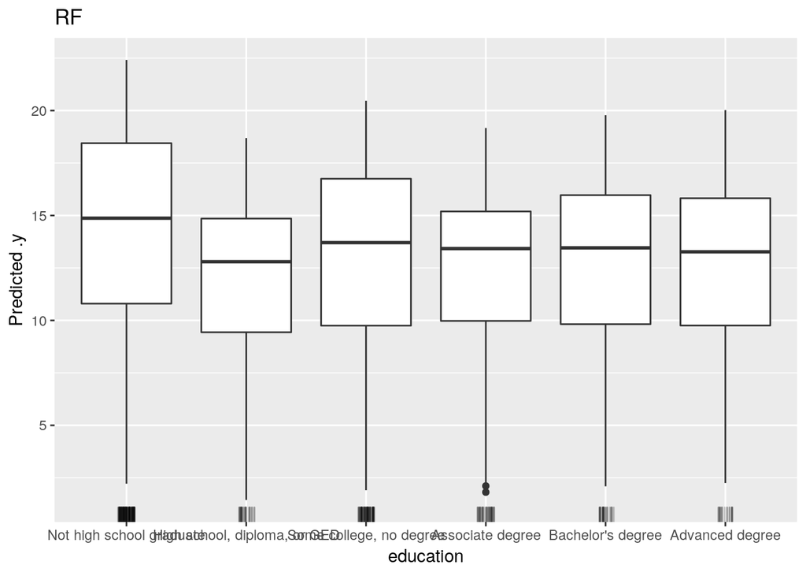

```r
p3 <- Partial$new(predictor.rf, "education") %>% plot() + ggtitle("RF")
p3
```

Activity 1. Create new partial dependence plots to examine different variables such as `age`, `time_pni`, `citizenship`, and `hs_type`.

### Interaction strength

We can also observe how variables in the model interact with each other. The first plot shows how much the variation in the predicted outcome for that variable depends on its interaction with other variables. The scale ranges from 0, where none of the variation for that variable depends on interactions and 1, where all the variation depends on that outcome.

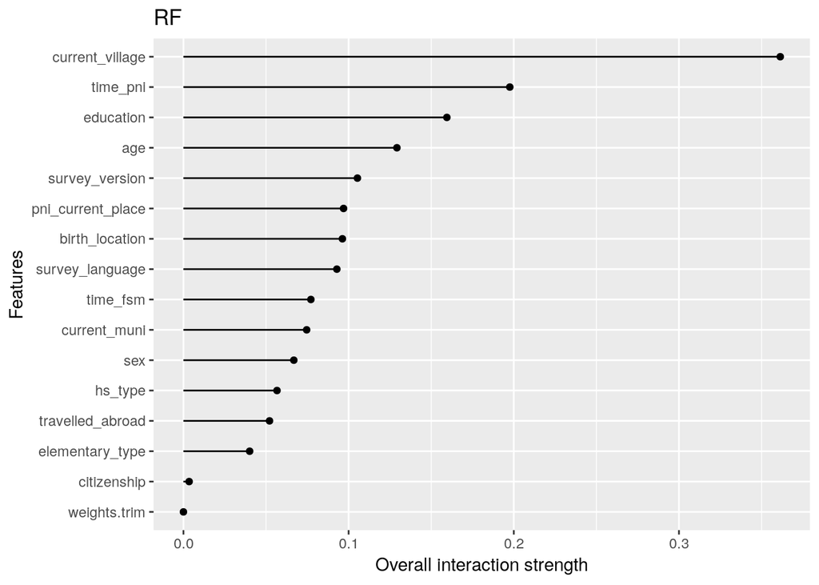

```r
p4  <- Interaction$new(predictor.rf) %>% plot() + ggtitle("RF")
p4
```

Specific variables can also be selected to see how much the interact with other variables. In the example below `education` is selected.

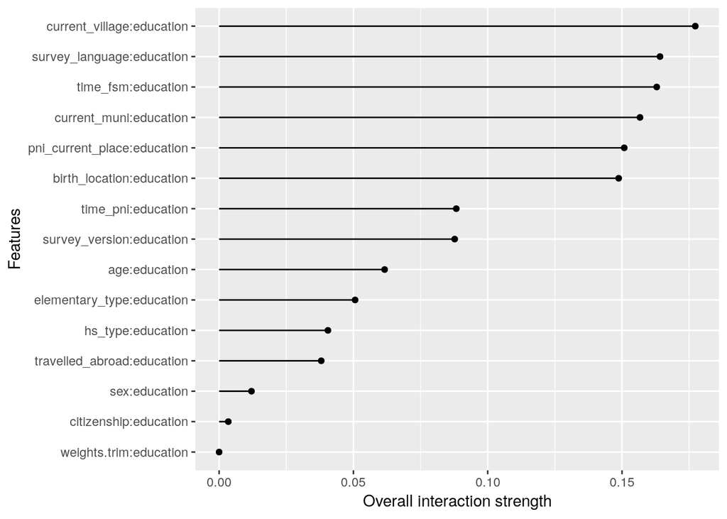

```r
p5 <- Interaction$new(predictor.rf, feature = "education") %>% plot()
p5
```

Activity 2. Change the variable in the interaction plot to see the strength of its interaction with other variables.

### Local Interpretable Model-Agnostic Explanations (LIME)

Since random forest models can be very complex, we can select specific individuals to see how their unique characteristics led to the predicted outcome. To demonstrate this, we select the individual with the highest predicted `highest_pni` and the lowest.

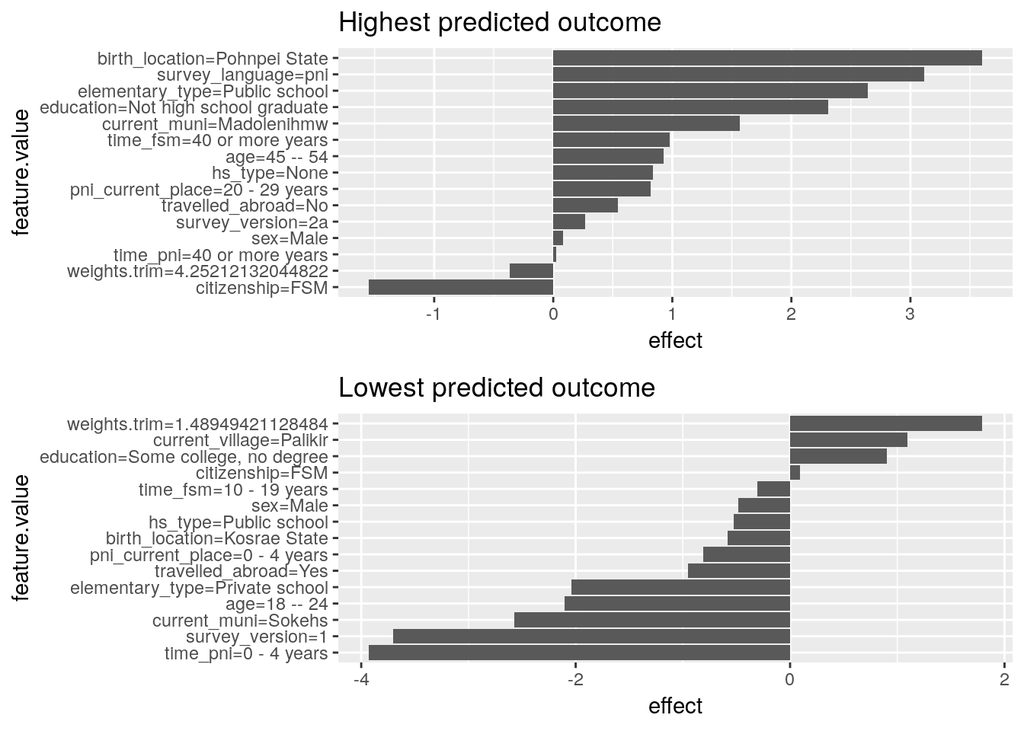

```r
high <- h2o.predict(rf1, train.h2o)
high <- high$predict
high <- as.vector(high)
high <- which.max(high)

low  <- predict(rf1, train.h2o)
low <- low$predict
low <- as.vector(low)
low <- which.min(low)

high_prob_ob <- features[high, ]
low_prob_ob  <- features[low, ]

p6  <- LocalModel$new(predictor.rf, k = 15, x.interest = high_prob_ob) %>% plot() + ggtitle("Highest predicted outcome")

p7  <- LocalModel$new(predictor.rf, k = 15, x.interest = low_prob_ob) %>% plot() + ggtitle("Lowest predicted outcome")

gridExtra::grid.arrange(p6, p7, nrow = 2, ncol=1)
```

Activity 3. Change the LIME plots above to other individuals. You can do that by finding individuals with certain characteristics or by just selecting a certain row number such as with `observation <- features[109, ]` to select row 109 and then in the plot code change the `x.interest` to `x.interest = observation`. For a more complicated version, try to find the individual with the average predicted outcome and display the LIME plot for them.

Activity 4. This is a more advanced activity. Extract the highest 10 predicted outcomes and display them as a table.